# 607 - HW 10 - Text Mining

Jeff Shamp

2020-04-01

# Text Mining

We are to start this assignment by producing a working version of the example used in “Text Mining with R”, chapter 2.

## Base Code

First let’s simply reproduce the code so that things are in the correct place.

```r
tidy_books <- austen_books() %>%
  group_by(book) %>%
  mutate(linenumber = row_number(),
         chapter = cumsum(str_detect(text, regex("^chapter [\\divxlc]",
                                                 ignore_case = TRUE)))) %>%
  ungroup() %>%
  unnest_tokens(word, text)

nrc_joy <- get_sentiments("nrc") %>%
  filter(sentiment == "anger")

DT::datatable(tidy_books %>%
  filter(book == "Emma") %>%
  inner_join(nrc_joy) %>%
  count(word, sort = TRUE),
         extensions = c('FixedColumns',"FixedHeader"),
          options = list(scrollX = TRUE,
                         paging=TRUE,
                         fixedHeader=TRUE))
```

|  | word | n |
| --- | --- | --- |
| 1 | ill | 72 |
| 2 | bad | 60 |
| 3 | feeling | 56 |
| 4 | bear | 52 |
| 5 | words | 49 |
| 6 | obliging | 34 |
| 7 | evil | 33 |
| 8 | difficulty | 30 |
| 9 | spite | 24 |
| 10 | loss | 23 |

[output cut: 303 more lines]

Here we brought in the Jane Austen corpus and the NRC lexicon from chapter 2 in “Text Mining with R”.

The NRC license can be found [here](https://saifmohammad.com/WebPages/NRC-Emotion-Lexicon.htm)

## New Corpus - Mody Dick

Let’s move on to another famous NLP corpus, Hermin Melville’s, “Moby Dick”. For the uninitiated, a summary of the book is [here](https://americanliterature.com/author/herman-melville/book/moby-dick-or-the-whale/summary)

We will be using the `gutnebergr` package to download the ’Moby Dick" corpus. There are several options, id number 2701 has the full text and is public domain.

```r
DT::datatable(gutenberg_metadata %>%
  filter(author == "Melville, Herman") %>%
  select(gutenberg_id, title, rights, has_text),
              extensions = c('FixedColumns',"FixedHeader"),
              options = list(scrollX = TRUE,
                         paging=TRUE,
                         fixedHeader=TRUE))
```

|  | gutenberg_id | title | rights | has_text |
| --- | --- | --- | --- | --- |
| 1 | 15 | Moby Dick | Public domain in the USA. | True |
| 2 | 1900 | Typee: A Romance of the South Seas | Public domain in the USA. | True |
| 3 | 2489 | Moby Dick; Or, The Whale | Public domain in the USA. | True |
| 4 | 2694 | I and My Chimney | Public domain in the USA. | True |
| 5 | 2701 | Moby Dick; Or, The Whale | Public domain in the USA. | True |
| 6 | 4045 | Omoo: Adventures in the South Seas | Public domain in the USA. | True |
| 7 | 8118 | Redburn. His First Voyage Being the Sailor Boy Confessions and Reminiscences of the Son-Of-A-Gentleman in the Merchant Navy | Public domain in the USA. | True |
| 8 | 9146 | I and my Chimney | Copyrighted. Read the copyright notice inside this book for details. | False |
| 9 | 9147 | Moby Dick | Copyrighted. Read the copyright notice inside this book for details. | False |
| 10 | 9268 | Omoo: Adventures in the South Seas | Copyrighted. Read the copyright notice inside this book for details. | False |

[output cut: 14 more lines]

Download the file.

```r
moby_dick<-gutenberg_download(2701)
```

```
## Determining mirror for Project Gutenberg from http://www.gutenberg.org/robot/harvest
```

```
## Using mirror http://aleph.gutenberg.org
```

Basic Preprocessing to assign and index for the lines and remove the whitespace.

```r
moby_dick<- moby_dick %>%
                  filter(!text == "")
colnames(moby_dick) <- c("id", "text")
moby_dick[, "id"] <- rownames(moby_dick)
```

### Call Me Ishmael

The opening paragraph of Moby Dick is famous in its own right, if you have not read it, or not read it in some time, you are encouraged to do so below.

```r
str_break = function(x, width = 70L) {
  n = nchar(x)
  if (n <= width) return(x)
  n1 = seq(1L, n, by = width)
  n2 = seq(width, n, by = width)
  if (n %% width != 0) n2 = c(n2, n)
  substring(x, n1, n2)
}
```

```r
x<-apply(moby_dick[6:24,"text"], 2, paste, collapse=" ")
cat(str_break(x), sep = '\n')
```

```
## Call me Ishmael.  Some years ago--never mind how long precisely-- havi
## ng little or no money in my purse, and nothing particular to interest
## me on shore, I thought I would sail about a little and see the watery
## part of the world.  It is a way I have of driving off the spleen and r
## egulating the circulation. Whenever I find myself growing grim about t
## he mouth; whenever it is a damp, drizzly November in my soul; whenever
##  I find myself involuntarily pausing before coffin warehouses, and bri
## nging up the rear of every funeral I meet; and especially whenever my
## hypos get such an upper hand of me, that it requires a strong moral pr
## inciple to prevent me from deliberately stepping into the street, and
## methodically knocking people's hats off--then, I account it high time
## to get to sea as soon as I can.  This is my substitute for pistol and
## ball. With a philosophical flourish Cato throws himself upon his sword
## ; I quietly take to the ship.  There is nothing surprising in this. If
##  they but knew it, almost all men in their degree, some time or other,
##  cherish very nearly the same feelings towards the ocean with me.
```

## Sentiment Analysis

First we will process this down by word and include the lines and chapters in case we want them later.

```r
moby_dick_tokens<- moby_dick %>%
  mutate(linenumber = row_number(),
         chapter = cumsum(str_detect(text,
                                     regex("^CHAPTER [\\d]",
                                     ignore_case = TRUE)))) %>%
  mutate(chapter = chapter+1) %>%
  ungroup() %>%
  unnest_tokens(word, text)
```

### New Lexicon

From the “lexicon” package I am using the Augmented Sentiword Polarity Table. For reference see page 29 [in the documentation](https://cran.r-project.org/web/packages/lexicon/lexicon.pdf)

This package is not set up for tidyverse the way `bing`, `afinn`, and `nrc` are so we need to make some minor changes to make these work in a similar way. `hash_sentiment_sentiword` is the lexicon linked to above that I will be using.

```r
sentiword<-hash_sentiment_sentiword
names(sentiword)<-c("word", "value")
```

I’ll use a similar tactic as in the “Text Mining with R” and parse the sentiment by 80 line chunks. I’ll plot the sentiment by chapter and hue the sentiment by 80 line chunks (there are 135 chapters in the book)

```r
senti_word<- moby_dick_tokens %>%
  inner_join(sentiword) %>%
  group_by(index = linenumber %/% 80, chapter)%>%
  summarise(sentiment = sum(value)) %>%
  mutate(method = "SentiWord")
```

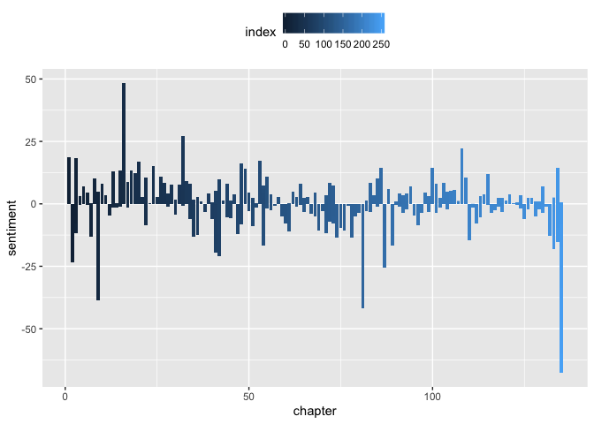

```r
senti_word%>%
  ggplot(aes(chapter, sentiment, fill=index)) +
  geom_col() +
  theme(legend.position = "top")
```

### SentiWord Lexicon Comparison

We can now compare the AFINN lexicon with sentiwords to see if the score are similar in trend. The scale WILL be different as SentiWord and AFINN have different scoring values. We are looking at trend here for comparison NOT whole number value.

```r
afinn_word<-moby_dick_tokens %>%
  inner_join(get_sentiments("afinn")) %>%
  group_by(index = linenumber %/% 80, chapter) %>%
  summarise(sentiment = sum(value)) %>%
  mutate(method = "afinn")
```

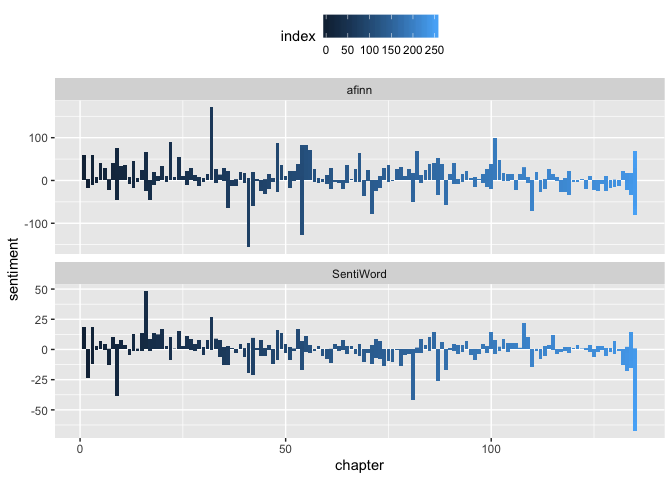

```r
twin_lex<-bind_rows(senti_word, afinn_word)
twin_lex%>%
  ggplot(aes(chapter, sentiment, fill=index)) +
  geom_col() +
  facet_wrap(~method, scales = "free_y", ncol=1) +
  theme(legend.position = "top")
```

These are reasonably similar, but there are notable expections. The section between chapters 55-80 seem to rather different. Let’s look at those more closely.

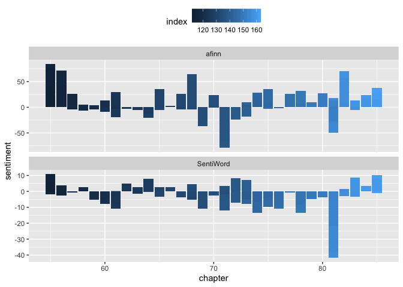

```r
bind_rows(senti_word, afinn_word) %>%
  filter(chapter >= 55 & chapter <= 85) %>%
  ggplot(aes(chapter, sentiment, fill=index)) +
  geom_col() +
  facet_wrap(~method, scales = "free_y", ncol=1) +
  theme(legend.position = "top")
```

So there is some confusion here between the two lexicons. Chapter 70-80 generally refer to the time after a whale has been captured. Ishmael describes the gruesome and and often harrowing process of dismembering a whale and procuring it’s oil from fat and tissue. Chapter 71 talks at length about the various religious sects of Christainity popular at the time. It seems AFINN categorizes these lines as pretty negative where as SentiWord is more neutral. We see a similar distinction in chapter 75 -80 where there is further discussion about both religion, the idea of karma, and the process of dismantling of a whale. SentiWord scores these ideas as generally negative where as AFINN sees them as positive. These two lexicons do agree quite well in the chapter 81, in which a new boat and crew are routinely mocked for there lack of knowledge and naivete.

These differences are somewhat expected considering the detail and nuance of Melville as well as his prose, sentence structure, and word choice.

## Second New Lexicon

Let’s bring in one more lexicon that is very different. The SlangSD lexicon for more informal text. See documentation for this lexicon [here](http://liangwu.me/slangsd/)

```r
slangword<-hash_sentiment_slangsd
names(slangword)<-c("word", "value")
```

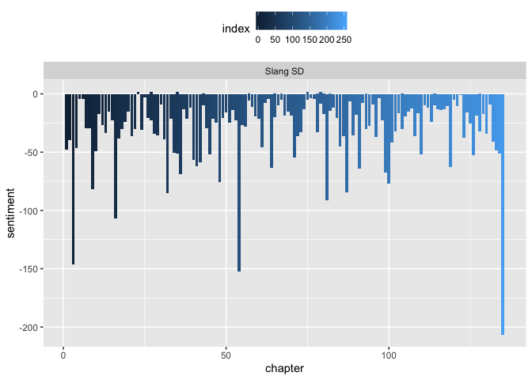

```r
moby_dick_tokens %>%
  inner_join(slangword) %>%
  group_by(index = linenumber %/% 80, chapter)%>%
  summarise(sentiment = sum(value)) %>%
  mutate(method = "Slang SD") %>%
  ggplot(aes(chapter, sentiment, fill=index)) +
  geom_col() +
  facet_wrap(~method, scales = "free_y", ncol=1) +
  theme(legend.position = "top")
```

Clearly the Slang SD lexicon is an example of clearly bad choice as it identifies everything as negative.